# DS 202 HW 6

Michael Egle | github: michaelegle

4/20/2020

## Top dogs

In this homework, you will try to reproduce the fantastic infographic for [top dogs](https://informationisbeautiful.net/visualizations/best-in-show-whats-the-top-data-dog/), originally produced by David McCandless. The raw data can be found [here](https://docs.google.com/spreadsheets/d/1l_HfF5EaN-QgnLc2UYdCc7L2CVrk0p3VdGB1godOyhk/edit#gid=10). You can download this file by File – Download As – Microsoft Excel (.xlsx).

**Submission instructions**: Create a folder named `ds202_hw6`, and name the RMarkDown file including your solutions `hw6.Rmd` under this folder. For the submission, create a GitHub repository named `ds202_hw6` under your GitHub account, and push both `hw6.Rmd` and the knitted `hw6.html` before the deadline. I will assume you use the same GitHub username as for your HW5 submission. The latest version of your homework appearing on GitHub before the deadline is graded. *It is crucial to follow the exact folder structure and file names*, so that your homework can be reproduced and graded by an automated script. This homework is **due on April 22** before class.

1. Import the data and clean appropriately. To read in the data, you can use `readxl::read_xlsx('fileNameHere', sheet='sheetNameHere')`. Required data are in the sheets `Best in show` and `Best in show full sheet`. Take extra care on the column names and the first few rows of the data frame after read in.

```r
library(tidyverse)
dogs <- readxl::read_xlsx('ds202_dawgs.xlsx', 'Best in show full sheet')
```

```
## * `` -> ...2
## * `` -> ...4
## * `` -> ...5
## * `` -> ...9
## * `` -> ...10
## * … and 59 more problems
```

```r
colnames(dogs) <- as.character(unlist(dogs[3, ]))
dogs = dogs[-(1:3), ]
```

Got rid of the ugly part above what was supposed to be the header, now let’s get rid of the columns we aren’t interested in.

```r
colnames(dogs)[3] <- "group"
colnames(dogs)[5] <- "data score"
colnames(dogs)[6] <- "popularity"
colnames(dogs)[12] <- "intelligence"
colnames(dogs)[32] <- "size"
```

```r
dogs <- dogs[, !duplicated(colnames(dogs))]
#  select(c(`Dog breed`, `data score`, `popularity`, `intelligence`, `size`, `group`))
```

```r
colnames(dogs)[2] <- "col2"
dogs <- dogs %>%
  select(`Dog breed`, `data score`, `popularity`, `intelligence`, `size`, `group`)
```

```r
dogs <- dogs %>%
  mutate_at(.vars = vars(`data score`, `popularity`, `intelligence`),
            .funs = funs(as.numeric))
dogs <- dogs %>%
  mutate(size = as.factor(size),
         group = as.factor(group))
```

Data is all cleaned and filtered

2. Create a graphics similar to the [top dogs](https://informationisbeautiful.net/visualizations/best-in-show-whats-the-top-data-dog/) figure. Your figure needs to display the following information with appropriate plotting elements:
- breed of dog X
- type of dog (work, toy, etc.) X
- size of dog X
- data score X
- popularity X
- intelligence of the dog X
- appropriate legends & explanation

```r
dogs <- dogs %>%
  filter(!is.na(`data score`), !is.na(popularity))

mean_pop <- mean(dogs$popularity)
mean_score <- mean(dogs$`data score`)
```

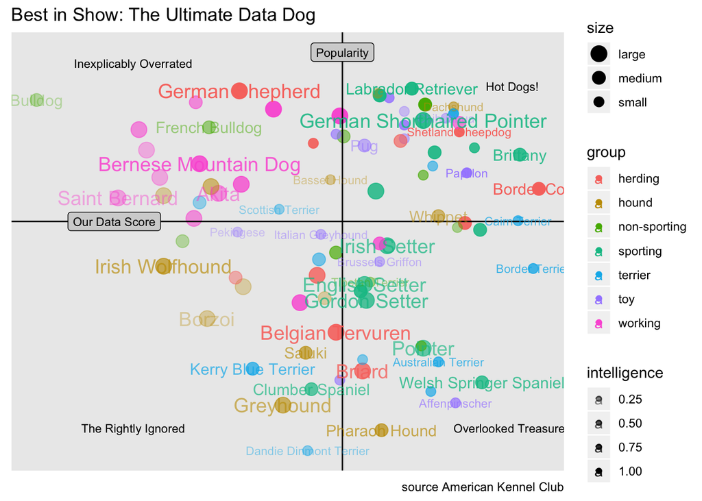

```r
dogs %>%
  ggplot(aes(x = `data score`, y = -popularity, color = group, size = size,
             label = `Dog breed`, alpha = intelligence)) +
  geom_point() +
  geom_vline(xintercept = mean_score) +
  geom_hline(yintercept = -mean_pop) +
  geom_text(mapping = aes(label = `Dog breed`), label.size = 10, check_overlap = TRUE) +
  scale_size_manual(values = c(5, 4, 3)) +
  scale_alpha_continuous(range = c(.3, 1)) +
  theme(axis.text.y = element_blank(),
        axis.text.x = element_blank(),
        axis.ticks = element_blank(),
        axis.title = element_blank(),
        line = element_blank()) +
  labs(title = "Best in Show: The Ultimate Data Dog",
       caption = "source American Kennel Club") +
  annotate(geom = "text", x = 1.5, y = 10, label = "Inexplicably Overrated", size = 3) +
  annotate(geom = "text", x = 1.5, y = -150, label = "The Rightly Ignored", size = 3) +
  annotate(geom = "text", x = 3.5, y = 0, label = "Hot Dogs!", size = 3) +
  annotate(geom = "text", x = 3.5, y = -150, label = "Overlooked Treasures", size = 3) +
  annotate(geom = "label", x = mean_score, y = 15, label = "Popularity", size = 3,
           fill = "lightgray") +
  annotate(geom = "label", x = 1.4, y = -mean_pop, label = "Our Data Score", size = 3,
           fill = "lightgray")
```

Hints and Notes:

- The breed of dog can be displayed without the silhouttes (text only is fine)
- Avoid (too much) overlaps!
- Choose a good color scheme.
- Your submission is supposed to be fully reproducible, i.e. the TA and I will ‘knit’ your submission in RStudio.